# Unemployment Analysis by County

Kyle Kirk’s Data Science Portfolio

## Abstract

I decided to look at the rates of unemployment to begin with, first looking over a few datasets from Nate Silver, data.gov, bigrquery and google. After exhausting many avenues of data I found a solid lead on the USDA website : [USDA.](https://www.ers.usda.gov/data-products/county-level-data-sets/download-data/)

Using this data I hope to find a deeper parallel between unemployment and the increase in automation technology. If a parallel is drawn, further projections on the coming unemployment crisis may be able to spur more governing bodies to take the needs of the workers and citizenry more seriously.

### 1. Discovery and Data Preparation

The first thing to be done is to load the libraries that we will be using during our investigation of the data.

```r
library("tidyverse")
library("tidyr")
library("dplyr")
library("readr")
library("stringr")
library("readxl")
```

The second thing is to import the data from the USDA government website so that we can go over it and make it Tidy.

```r
Unemployment <- read_excel("Unemployment.xls")
```

This data is incredibly wide, and although they are unique, they are a repeating pattern of four yearly data sets. We will be reducing this down into our four categorical factors and our four continuous.

> Categorical : FIPS, State, Area_name, year

> Continuous : civilian_labor, employed, unemployed, unemployment_rate

We will do this first by selecting the identifying information with the year in range (2007).

```r
clean_unemp <- select(Unemployment, 1,2,3,7,8,9,10)
```

We have the first year in place, but it is only in the title of the continuous data sets we have. So we need to add a year.

```r
clean_unemp$year = 2007
```

We need to change the data, because currently it looks like this :

```r
print(clean_unemp)
```

```
## # A tibble: 3,275 x 8
##     FIPS State Area_name Civilian_labor_… Employed_2007 Unemployed_2007
##    <dbl> <chr> <chr>                <dbl>         <dbl>           <dbl>
##  1     0 US    United S…        152191093     145156134         7034959
##  2  1000 AL    Alabama            2175612       2089127           86485
##  3  1001 AL    Autauga …            24383         23577             806
##  4  1003 AL    Baldwin …            82659         80099            2560
##  5  1005 AL    Barbour …            10334          9684             650
##  6  1007 AL    Bibb Cou…             8791          8432             359
##  7  1009 AL    Blount C…            26629         25780             849
##  8  1011 AL    Bullock …             3653          3308             345
##  9  1013 AL    Butler C…             9099          8539             560
## 10  1015 AL    Calhoun …            54861         52709            2152
## # … with 3,265 more rows, and 2 more variables: Unemployment_rate_2007 <dbl>,
## #   year <dbl>
```

We will be folding all the data under the current categorical (Civilian_labr_force_2007, Employed_2007, etc) and we can’t have that year staying the same, and in fact let’s clean up the rest of the names.

```r
colnames(clean_unemp)[colnames(clean_unemp) == "State"] <- "state"
colnames(clean_unemp)[colnames(clean_unemp) == "Area_name"] <- "county"
colnames(clean_unemp)[colnames(clean_unemp) == "Civilian_labor_force_2007"] <- "civilian_labor"
colnames(clean_unemp)[colnames(clean_unemp) == "Employed_2007"] <- "employed"
colnames(clean_unemp)[colnames(clean_unemp) == "Unemployed_2007"] <- "unemployed"
colnames(clean_unemp)[colnames(clean_unemp) == "Unemployment_rate_2007"] <- "unemployment_rate"
```

With this done, now the dataframe clean_unemp looks like this :

```r
print(clean_unemp)
```

```
## # A tibble: 3,275 x 8
##     FIPS state county  civilian_labor employed unemployed unemployment_ra…  year
##    <dbl> <chr> <chr>            <dbl>    <dbl>      <dbl>            <dbl> <dbl>
##  1     0 US    United…      152191093   1.45e8    7034959              4.6  2007
##  2  1000 AL    Alabama        2175612   2.09e6      86485              4    2007
##  3  1001 AL    Autaug…          24383   2.36e4        806              3.3  2007
##  4  1003 AL    Baldwi…          82659   8.01e4       2560              3.1  2007
##  5  1005 AL    Barbou…          10334   9.68e3        650              6.3  2007
##  6  1007 AL    Bibb C…           8791   8.43e3        359              4.1  2007
##  7  1009 AL    Blount…          26629   2.58e4        849              3.2  2007
##  8  1011 AL    Bulloc…           3653   3.31e3        345              9.4  2007
##  9  1013 AL    Butler…           9099   8.54e3        560              6.2  2007
## 10  1015 AL    Calhou…          54861   5.27e4       2152              3.9  2007
## # … with 3,265 more rows
```

With this solid base, we can continue to import by adding dataframes onto this. We will have to do this for each year. We can do this through some simple scripting.

```r
col = 11

for (n_year in 2008:2017){
  col2 = col+1
  col3 = col+2
  col4 = col+3
  temp_unemp <- select(Unemployment,1,2,3,col,col2,col3,col4)
  colnames(temp_unemp)[2] = "state"
  colnames(temp_unemp)[3] = "county"
  colnames(temp_unemp)[4] = "civilian_labor"
  colnames(temp_unemp)[5] = "employed"
  colnames(temp_unemp)[6] = "unemployed"
  colnames(temp_unemp)[7] = "unemployment_rate"
  temp_unemp$year=n_year
  clean_unemp <- rbind(clean_unemp, temp_unemp)
  col = col4+1
}
```

With this script run, we have created a more searchable dataframe. Where previously there had been 3,275 rows, now we have…

```r
print(clean_unemp)
```

```
## # A tibble: 36,025 x 8
##     FIPS state county  civilian_labor employed unemployed unemployment_ra…  year
##    <dbl> <chr> <chr>            <dbl>    <dbl>      <dbl>            <dbl> <dbl>
##  1     0 US    United…      152191093   1.45e8    7034959              4.6  2007
##  2  1000 AL    Alabama        2175612   2.09e6      86485              4    2007
##  3  1001 AL    Autaug…          24383   2.36e4        806              3.3  2007
##  4  1003 AL    Baldwi…          82659   8.01e4       2560              3.1  2007
##  5  1005 AL    Barbou…          10334   9.68e3        650              6.3  2007
##  6  1007 AL    Bibb C…           8791   8.43e3        359              4.1  2007
##  7  1009 AL    Blount…          26629   2.58e4        849              3.2  2007
##  8  1011 AL    Bulloc…           3653   3.31e3        345              9.4  2007
##  9  1013 AL    Butler…           9099   8.54e3        560              6.2  2007
## 10  1015 AL    Calhou…          54861   5.27e4       2152              3.9  2007
## # … with 36,015 more rows
```

*36,025* rows. All with the year their specific data is measured into, and a comparable county. This allows us to compare based off of State, County and Year or any of the other data sets. This is valuable, as our dataframe is now only eight wide, where it had been fifty six wide before.

A good example of this can be shown here in a graph, something we could not have done easily before we can now plot out with ggplot. We will first enable ggplot2 to allow us to flex some graphical prowess.

```r
library("ggplot2")
```

We have a yearly seperation of data, and this gives us the ability to hone our focus onto a location, and a measurement (civilian_labor, employed, unemployed, unemployment_rate) with a year range.

Let’s focus in on Butler County, Alabama. We’re going to create a tibble to hold the data with unique year values.

```r
butler_county <- clean_unemp[clean_unemp$county == 'Butler County, AL',]
```

We have created a tibble named butler_county, this means that we can focus solely upon the data over the years in Butler County, AL. We’re going to put the tibble into a plot variable so that we can act on it directly without having to repeat code that may be confusing.

```r
butler_plot <- ggplot(butler_county, aes(x=year, y=unemployment_rate, label=unemployment_rate))
```

Now that it is in an object that we can manipulate more easily, we will walk through three different types of graphs. First, we will apply it to a geometric line *(geom_line())*.

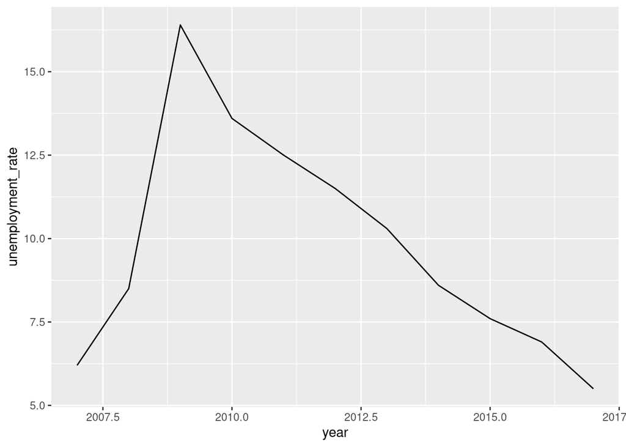

```r
butler_plot + geom_line()
```

Now let’s take a look at geom_step(), which will give us a stronger differentiation between years.

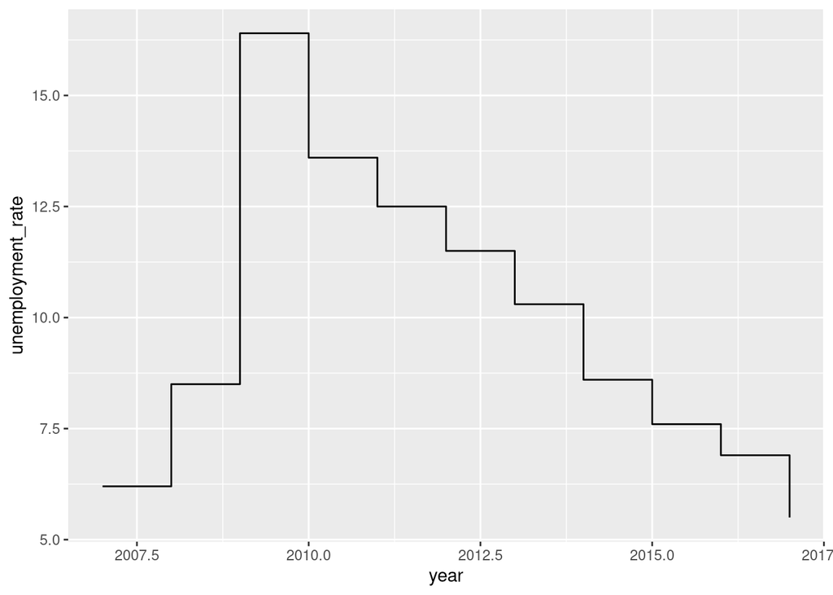

```r
butler_plot + geom_step()
```

This also gives us a much better understanding, we can see the decrease per year, but in the declining years between 2010 and 2015 it is hard to tell how much it is decreasing in relation to the previous year. I think the better graph will be something with color and bars. In addition to this placing the value in the bar will give us quick access instead of having to compare it to the Y-axis.

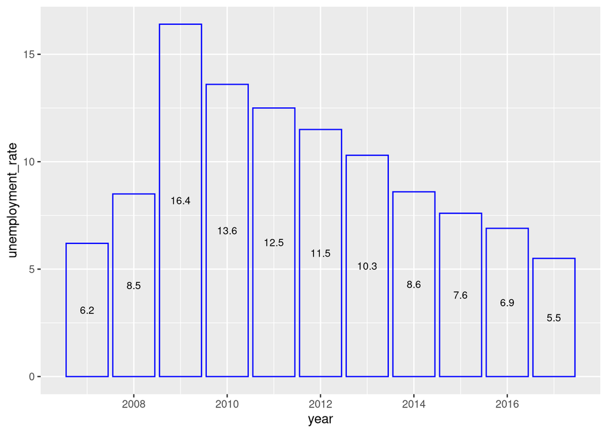

```r
butler_plot + geom_bar(stat = "identity", color = "Blue", fill="light blue") + geom_text(size = 3, position = position_stack(vjust = 0.5))
```

Once we draw in a secondary data set on the increase in automation in technology we can see how these compare to each other. We will need to reduce cohort data (such as the mortage bubble crisis) and we can probably do that by looking at the standard deviation from the United States average.

```r
usa_data <- clean_unemp[clean_unemp$county == 'United States',]
usa_plot <- ggplot(usa_data, aes(x=year, y=unemployment_rate, label=unemployment_rate))
```

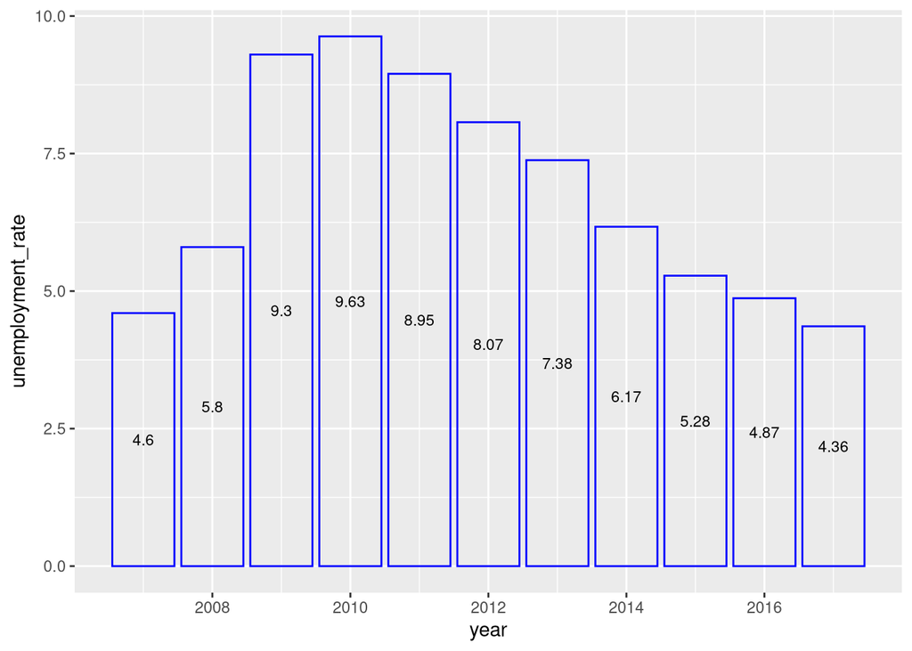

```r
usa_plot + geom_bar(stat = "identity", color = "Blue", fill="light blue") + geom_text(size = 3, position = position_stack(vjust = 0.5))
```

Above we can see the country wide average. This is a good baseline that we can then focus in further on.